# Development Metrics

Andrew Villeneuve

08/10/2020

### The Study

Eggs laid by broodstock *Urosalpinx cinerea* from two Pacific sites and five Atlantic sites were collected and separated by population in individual tea strainers in two acclimation temperatures, 20° and 24°C. We reared these snails for use in the $CT_{max}$ experiment, but we were able to also gain valuable information on the embryo clutch/egg capsule, hatch time, and survival for each population.

## Number of Embryos

After being laid and we had labeled individual egg cases in tea strainers, each egg case was photographed at least three times during development using a Leica digital microscope. From these photographs, we were able to establish the starting number of embryos in each capsule. The multiple photos allowed us to account embryos that may have been hidden in other photos. We did not count nurse embryos.

## Hatching time

We checked adult broodstock every day for evidence of egg capsule laying. When capsules were identified, ideally with the mother still laying eggs, we removed each egg capsule, marked the mother, and noted the date of laying. Once the egg capsules were distributed into their separate tea strainers in respective acclimations, we checked daily for hatching. On the day of hatch, we marked the date. We counted an egg as hatched once the first juvenile crawled out of the top of the egg capsule, thus allowing for the free exchange of water inside the capsule and the ability for all juveniles to crawl out.

## Survivorship

# site

Two-letter abbreviation of sites used. Correspond to the following sites:

```r
site.meta<-data.table(siteID = c("GB","WH","OY","BF","FB","HM","TO"),site=c("Great Bay","Woods Hole","Oyster","Beaufort","Folly Beach","Humboldt","TO"),state=c("NH","MA","VA","NC","SC","CA","CA"))
site.meta
```

| siteID | site | state |
| --- | --- | --- |
| GB | Great Bay | NH |
| WH | Woods Hole | MA |
| OY | Oyster | VA |
| BF | Beaufort | NC |
| FB | Folly Beach | SC |
| HM | Humboldt | CA |
| TO | TO | CA |

# lat

Latitude of the site

# ocean

Used to sort out Atlantic and Pacific sites. A = Atlantic, P = Pacific

# acc

Acc is the acclimation temperature. Each population was reared in either 20°C or 24°C seawater (30PSU). We are interested in knowing if acclimation temperature will expose signs of plasticity in developmental rate and esurvivorhip for each population.

# no.embryos

The maxmum number of embryos counted in each egg capsule. This number sometimes was determined by advancing forward to later photos when embryos were obscured. “Nurse eggs” were not counted.

# lay.date

Date egg capsules were first observed within broodstock tanks (m/dd/yyyy)

# date.hatched

Date at which the first snail was observed having emerged from the egg capsule OR date at which the egg capsule operculum was observed to be open, allowing seawater to enter the egg capsule freely. (m/dd/yyyy)

# no.hatch

Number of hatchling snails observed on date.hatched that were alive. Dead embryos were not counted.

# Time.to.hatch

Developmental time, calculated as the difference between lay.date and date.hatched. Measured in days

# survivor

Survivorship proportion for each egg capsule, calculated as no.hatch/no.embryos

# no.dead

Number of unsuccessful embryos per egg capsule, calculated as no.embryos - no.hatch

# mean

Mean SST for each site (degrees celsius)

# s.mean

Summer mean SST for each site, calculated as the range in values between 06/01 and 09/30. (degrees celsius)

# q.mean

Upper Quartile summer mean for each site, calculated as the upper 75th percentile of temperature observations over the summer (between 06/01 and 09/30). (degrees celsius)

# t.mean

Upper 90th percentile summer mean for each site, calculated over the summer (between 06/01 and 09/30). (degrees celsius)

# max

Maximum temperature for each site (degrees)

## Testing for collinearity

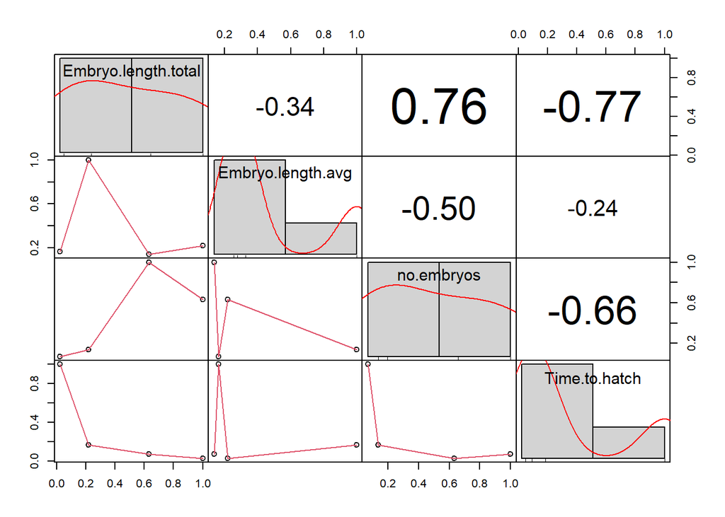

Does mom weight or mom length correlate with number of embryos? They do not appear to, but We will include moms in mixed effect models

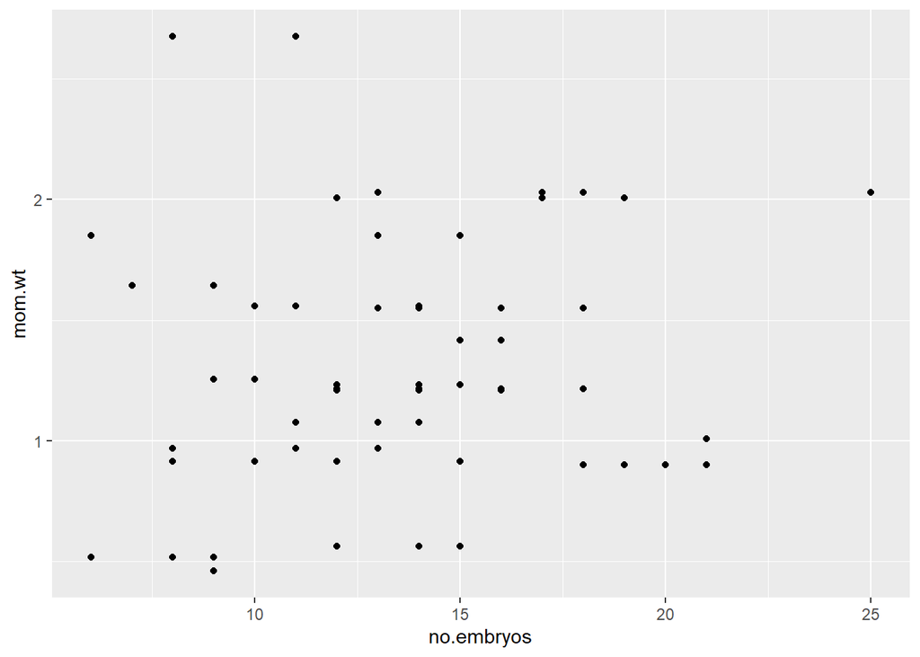

```
##
## Call:
## lm(formula = no.embryos ~ mom.wt, data = data.moms)
##
## Residuals:
##     Min      1Q  Median      3Q     Max
## -7.5936 -3.1035 -0.1158  2.5908 11.2947
##
## Coefficients:
##             Estimate Std. Error t value Pr(>|t|)
## (Intercept)  12.4520     1.3378   9.308 1.91e-13 ***
## mom.wt        0.6171     0.9303   0.663     0.51
## ---
## Signif. codes:  0 '***' 0.001 '**' 0.01 '*' 0.05 '.' 0.1 ' ' 1
##
## Residual standard error: 3.976 on 63 degrees of freedom
## Multiple R-squared:  0.006937,   Adjusted R-squared:  -0.008826
## F-statistic: 0.4401 on 1 and 63 DF,  p-value: 0.5095
```

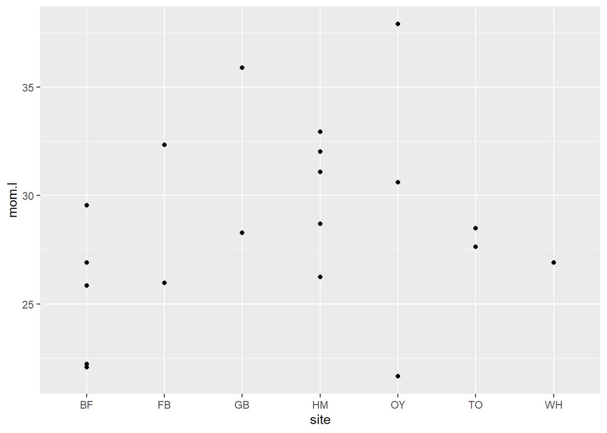

## Number of Embryos analysis

|  | Modnames | K | AICc | Delta_AICc | ModelLik | AICcWt | LL | Cum.Wt |
| --- | --- | --- | --- | --- | --- | --- | --- | --- |
| 7 | Mod7 | 4 | 456.1664 | 0.0000000 | 1.00000000 | 0.29308086 | -223.8451 | 0.2930809 |
| 6 | Mod6 | 4 | 456.6653 | 0.4989289 | 0.77921796 | 0.22837387 | -224.0946 | 0.5214547 |
| 5 | Mod5 | 4 | 457.2111 | 1.0447618 | 0.59310673 | 0.17382823 | -224.3675 | 0.6952830 |
| 4 | Mod4 | 4 | 457.5886 | 1.4221878 | 0.49110668 | 0.14393397 | -224.5562 | 0.8392169 |
| 1 | Mod1 | 3 | 460.1906 | 4.0242189 | 0.13370633 | 0.03918677 | -226.9541 | 0.8784037 |
| 9 | Mod9 | 4 | 460.3218 | 4.1554417 | 0.12521527 | 0.03669820 | -225.9228 | 0.9151019 |
| 3 | Mod3 | 4 | 460.6224 | 4.4560699 | 0.10773994 | 0.03157651 | -226.0731 | 0.9466784 |
| 2 | Mod2 | 4 | 460.8106 | 4.6442241 | 0.09806624 | 0.02874134 | -226.1672 | 0.9754198 |
| 8 | Mod8 | 4 | 461.1234 | 4.9570109 | 0.08386848 | 0.02458025 | -226.3236 | 1.0000000 |

```
##       q.mean       t.mean       s.mean         mean          lat
## 0.0006352571 0.0017826690 0.0004141762 0.0237558563 0.0231219485
```

```
##
## Call:
## model.avg(object = modeavelist)
##
## Component model call:
## glmmTMB(formula = no.embryos ~ <4 unique rhs>, data = data, family =
##      compois, ziformula = ~0, dispformula = ~1)
##
## Component models:
##   df  logLik   AICc delta weight
## 1  4 -223.85 456.17  0.00   0.35
## 4  4 -224.09 456.67  0.50   0.27
## 2  4 -224.37 457.21  1.04   0.21
## 3  4 -224.56 457.59  1.42   0.17
##
## Term codes:
##    cond(max) cond(q.mean) cond(s.mean) cond(t.mean)
##            1            2            3            4
##
## Model-averaged coefficients:
## (full average)
##               Estimate Std. Error Adjusted SE z value Pr(>|z|)
## cond((Int))   3.298669   0.337097    0.341605   9.656   <2e-16 ***
## cond(max)    -0.011391   0.017147    0.017191   0.663    0.508
## cond(t.mean) -0.008678   0.015626    0.015666   0.554    0.580
## cond(q.mean) -0.006218   0.013426    0.013461   0.462    0.644
## cond(s.mean) -0.004670   0.011368    0.011398   0.410    0.682
##
## (conditional average)
##              Estimate Std. Error Adjusted SE z value Pr(>|z|)
## cond((Int))   3.29867    0.33710     0.34160   9.656  < 2e-16 ***
## cond(max)    -0.03262    0.01223     0.01241   2.629  0.00857 **
## cond(t.mean) -0.03189    0.01253     0.01271   2.508  0.01214 *
## cond(q.mean) -0.03002    0.01248     0.01266   2.372  0.01768 *
## cond(s.mean) -0.02723    0.01180     0.01197   2.274  0.02294 *
## ---
## Signif. codes:  0 '***' 0.001 '**' 0.01 '*' 0.05 '.' 0.1 ' ' 1
```

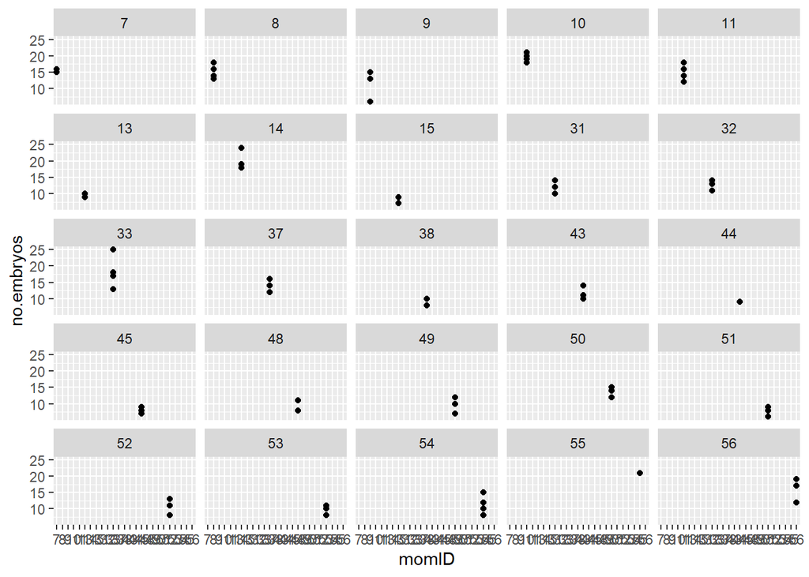

```
##  Family: compois  ( log )
## Formula:          no.embryos ~ max + (1 | momID)
## Data: data
##
##      AIC      BIC   logLik deviance df.resid
##    454.7    464.7   -223.4    446.7       85
##
## Random effects:
##
## Conditional model:
##  Groups Name        Variance Std.Dev.
##  momID  (Intercept) 0.05573  0.2361
## Number of obs: 89, groups:  momID, 25
##
## Overdispersion parameter for compois family (): 0.425
##
## Conditional model:
##             Estimate Std. Error z value Pr(>|z|)
## (Intercept)  3.37139    0.34209   9.855   <2e-16 ***
## max         -0.03124    0.01225  -2.550   0.0108 *
## ---
## Signif. codes:  0 '***' 0.001 '**' 0.01 '*' 0.05 '.' 0.1 ' ' 1
```

```
## [1] 0.7767647
```

```
##      chisq      ratio        rdf          p
## 67.0169090  0.7884342 85.0000000  0.9248531
```

```
## # R2 for Mixed Models
##
##   Conditional R2: 0.295
##      Marginal R2: 0.059
```

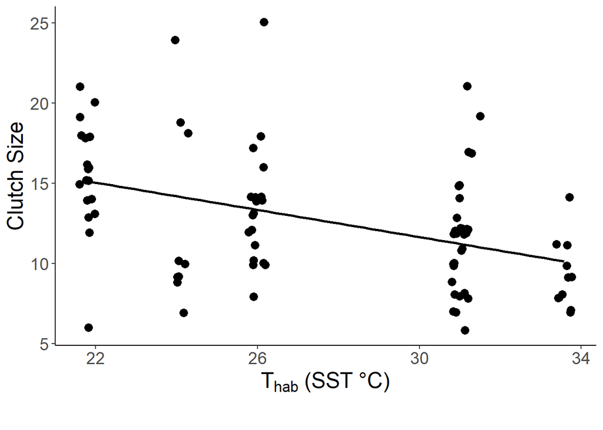

## Time to hatch analysis

|  | Modnames | K | AICc | Delta_AICc | ModelLik | AICcWt | LL | Cum.Wt |
| --- | --- | --- | --- | --- | --- | --- | --- | --- |
| 31 | clutch_lat*acc | 6 | 356.6294 | 0.0000000 | 1.000000e+00 | 2.710217e-01 | -171.8025 | 0.2710217 |
| 12 | lat*acc | 6 | 356.7147 | 0.0853108 | 9.582415e-01 | 2.597043e-01 | -171.8452 | 0.5307260 |
| 13 | mean*acc | 6 | 357.3261 | 0.6966859 | 7.058568e-01 | 1.913025e-01 | -172.1509 | 0.7220285 |
| 32 | clutch_mean*acc | 6 | 357.3535 | 0.7240915 | 6.962505e-01 | 1.886990e-01 | -172.1646 | 0.9107275 |
| 8 | mean+acc | 5 | 361.1902 | 4.5608241 | 1.022421e-01 | 2.770982e-02 | -175.2337 | 0.9384374 |
| 27 | clutch_mean+acc | 5 | 361.3978 | 4.7684104 | 9.216220e-02 | 2.497796e-02 | -175.3375 | 0.9634153 |
| 7 | lat+acc | 5 | 362.5802 | 5.9507775 | 5.102759e-02 | 1.382959e-02 | -175.9286 | 0.9772449 |
| 26 | clutch_lat+acc | 5 | 362.8286 | 6.1991735 | 4.506782e-02 | 1.221436e-02 | -176.0528 | 0.9894593 |
| 14 | s.mean*acc | 6 | 367.2418 | 10.6124248 | 4.960680e-03 | 1.344452e-03 | -177.1087 | 0.9908037 |
| 33 | clutch_s.mean*acc | 6 | 367.4269 | 10.7975318 | 4.522158e-03 | 1.225603e-03 | -177.2013 | 0.9920293 |

[output cut: 28 more lines]

```
##       q.mean       t.mean       s.mean         mean          lat   no.embryos
## 0.0006131231 0.0016308927 0.0003972143 0.0214173486 0.0226580855 0.5773288033
##     survivor
## 0.6983107702
```

```
##
## Call:
## model.avg(object = a, b)
##
## Component model call:
## glmmTMB(formula = Time.to.hatch ~ <2 unique rhs>, data = data, family =
##      gaussian, ziformula = ~0, dispformula = ~1)
##
## Component models:
##     df  logLik   AICc delta weight
## 124  6 -171.85 356.71  0.00   0.58
## 135  6 -172.15 357.33  0.61   0.42
##
## Term codes:
##      cond(acc)      cond(lat)     cond(mean)  cond(acc:lat) cond(acc:mean)
##              1              2              3              4              5
##
## Model-averaged coefficients:
## (full average)
##                  Estimate Std. Error Adjusted SE z value Pr(>|z|)
## cond((Int))       32.4505    12.1039     12.1155   2.678   0.0074 **
## cond(lat)          0.2424     0.2208      0.2212   1.096   0.2730
## cond(acc24)       -6.3649     8.2058      8.2229   0.774   0.4389
## cond(acc24:lat)   -0.1638     0.1587      0.1592   1.028   0.3037
## cond(mean)        -0.1944     0.2367      0.2370   0.820   0.4123
## cond(acc24:mean)   0.1158     0.1520      0.1525   0.759   0.4478
##
## (conditional average)
##                  Estimate Std. Error Adjusted SE z value Pr(>|z|)
## cond((Int))      32.45052   12.10387    12.11549   2.678  0.00740 **
## cond(lat)         0.42102    0.09736     0.09881   4.261 2.03e-05 ***
## cond(acc24)      -6.36490    8.20583     8.22293   0.774  0.43891
## cond(acc24:lat)  -0.28441    0.09716     0.09860   2.884  0.00392 **
## cond(mean)       -0.45819    0.10605     0.10762   4.258 2.07e-05 ***
## cond(acc24:mean)  0.27295    0.10772     0.10931   2.497  0.01253 *
## ---
## Signif. codes:  0 '***' 0.001 '**' 0.01 '*' 0.05 '.' 0.1 ' ' 1
```

```
##  Family: gaussian  ( identity )
## Formula:          Time.to.hatch ~ mean * acc + (1 | hatchID)
## Data: data
##
##      AIC      BIC   logLik deviance df.resid
##    356.3    371.3   -172.2    344.3       83
##
## Random effects:
##
## Conditional model:
##  Groups   Name        Variance Std.Dev.
##  hatchID  (Intercept) 0.955    0.9772
##  Residual             2.161    1.4699
## Number of obs: 89, groups:  hatchID, 26
##
## Dispersion estimate for gaussian family (sigma^2): 2.16
##
## Conditional model:
##             Estimate Std. Error z value Pr(>|z|)
## (Intercept)  46.1430     1.7556  26.283  < 2e-16 ***
## mean         -0.4632     0.1054  -4.397  1.1e-05 ***
## acc24       -15.4300     1.8439  -8.368  < 2e-16 ***
## mean:acc24    0.2863     0.1111   2.577  0.00996 **
## ---
## Signif. codes:  0 '***' 0.001 '**' 0.01 '*' 0.05 '.' 0.1 ' ' 1
```

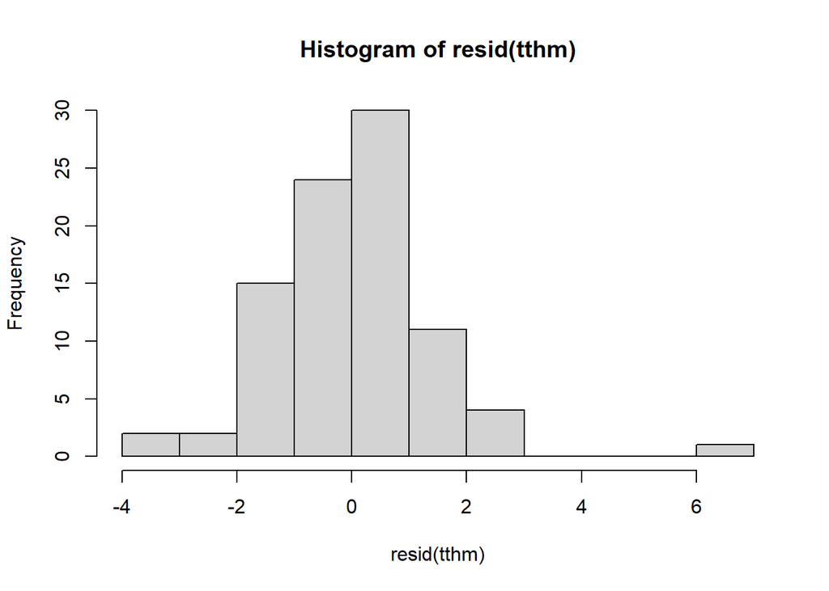

```
##           R2m       R2c
## [1,] 0.906739 0.9353247
```

| site | acc | Time.to.hatch |
| --- | --- | --- |
| BF | 20 | 36.60000 |
| BF | 24 | 26.88235 |
| FB | 20 | 36.50000 |
| FB | 24 | 29.33333 |
| GB | 20 | 41.80000 |
| GB | 24 | 29.16667 |
| HM | 20 | 38.33333 |
| HM | 24 | 27.66667 |
| OY | 20 | 39.00000 |
| OY | 24 | 27.57143 |

[output cut: 4 more lines]

| site | acc | Time.to.hatch |
| --- | --- | --- |
| BF | 20 | 1.5055453 |
| BF | 24 | 1.1114379 |
| FB | 20 | 3.5355339 |
| FB | 24 | 0.5773503 |
| GB | 20 | 2.5884358 |
| GB | 24 | 1.4719601 |
| HM | 20 | 1.8027756 |
| HM | 24 | 1.0000000 |
| OY | 20 | 0.0000000 |
| OY | 24 | 1.1338934 |

[output cut: 4 more lines]

Now that we have a model averaged summary of our data, we will plot one of the best fit models (mean temperature) for visualization.

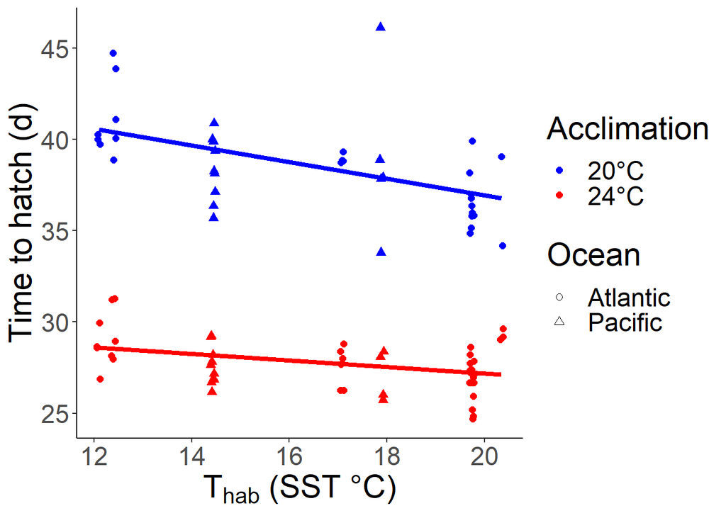

## Survivorship analysis

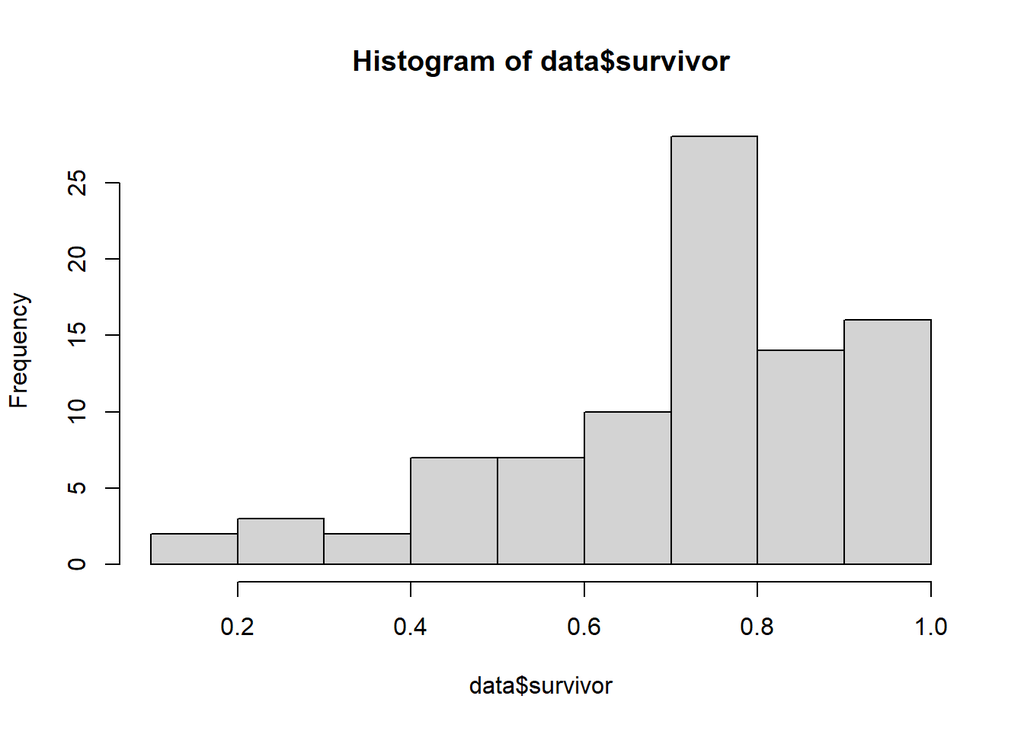

|  | Modnames | K | AICc | Delta_AICc | ModelLik | AICcWt | LL | Cum.Wt |
| --- | --- | --- | --- | --- | --- | --- | --- | --- |
| 5 | clutch_q.mean | 3 | 402.2908 | 0.0000000 | 1.00000000 | 0.146193927 | -198.0042 | 0.1461939 |
| 4 | clutch_s.mean | 3 | 402.4044 | 0.1136346 | 0.94476666 | 0.138119149 | -198.0610 | 0.2843131 |
| 6 | clutch_t.mean | 3 | 402.6710 | 0.3802187 | 0.82686872 | 0.120883186 | -198.1943 | 0.4051963 |
| 10 | clutch_q.mean+acc | 4 | 403.8225 | 1.5317143 | 0.46493523 | 0.067970708 | -197.6731 | 0.4731670 |
| 2 | clutch_lat | 3 | 403.8417 | 1.5509118 | 0.46049379 | 0.067321395 | -198.7797 | 0.5404884 |
| 9 | clutch_s.mean+acc | 4 | 403.9361 | 1.6452821 | 0.43926999 | 0.064218604 | -197.7299 | 0.6047070 |
| 19 | clutch_max | 3 | 404.0494 | 1.7586783 | 0.41505711 | 0.060678829 | -198.8835 | 0.6653858 |
| 11 | clutch_t.mean+acc | 4 | 404.2153 | 1.9245553 | 0.38202179 | 0.055849265 | -197.8696 | 0.7212351 |
| 3 | clutch_mean | 3 | 404.7208 | 2.4300379 | 0.29670439 | 0.043376380 | -199.2192 | 0.7646114 |
| 15 | clutch_q.mean*acc | 5 | 405.1037 | 2.8129658 | 0.24500347 | 0.035818019 | -197.1904 | 0.8004295 |

[output cut: 9 more lines]

|  | Modnames | K | AICc | Delta_AICc | ModelLik | AICcWt | LL | Cum.Wt |
| --- | --- | --- | --- | --- | --- | --- | --- | --- |
| 5 | clutch_q.mean | 3 | 402.2908 | 0.0000000 | 1.0000000 | 0.14619393 | -198.0042 | 0.1461939 |
| 4 | clutch_s.mean | 3 | 402.4044 | 0.1136346 | 0.9447667 | 0.13811915 | -198.0610 | 0.2843131 |
| 6 | clutch_t.mean | 3 | 402.6710 | 0.3802187 | 0.8268687 | 0.12088319 | -198.1943 | 0.4051963 |
| 10 | clutch_q.mean+acc | 4 | 403.8225 | 1.5317143 | 0.4649352 | 0.06797071 | -197.6731 | 0.4731670 |
| 2 | clutch_lat | 3 | 403.8417 | 1.5509118 | 0.4604938 | 0.06732140 | -198.7797 | 0.5404884 |
| 9 | clutch_s.mean+acc | 4 | 403.9361 | 1.6452821 | 0.4392700 | 0.06421860 | -197.7299 | 0.6047070 |
| 19 | clutch_max | 3 | 404.0494 | 1.7586783 | 0.4150571 | 0.06067883 | -198.8835 | 0.6653858 |
| 11 | clutch_t.mean+acc | 4 | 404.2153 | 1.9245553 | 0.3820218 | 0.05584927 | -197.8696 | 0.7212351 |

```
##
## Call:
## model.avg(object = a, b, c, d, e, g, h, i)
##
## Component model call:
## glmmTMB(formula = y ~ <8 unique rhs>, data = data, family = binomial,
##      ziformula = ~0, dispformula = ~1)
##
## Component models:
##    df  logLik   AICc delta weight
## 4   3 -198.00 402.29  0.00   0.20
## 5   3 -198.06 402.40  0.11   0.19
## 6   3 -198.19 402.67  0.38   0.17
## 14  4 -197.67 403.82  1.53   0.09
## 2   3 -198.78 403.84  1.55   0.09
## 15  4 -197.73 403.94  1.65   0.09
## 3   3 -198.88 404.05  1.76   0.08
## 16  4 -197.87 404.22  1.92   0.08
##
## Term codes:
##    cond(acc)    cond(lat)    cond(max) cond(q.mean) cond(s.mean) cond(t.mean)
##            1            2            3            4            5            6
##
## Model-averaged coefficients:
## (full average)
##               Estimate Std. Error Adjusted SE z value Pr(>|z|)
## cond((Int))  -0.407109   1.769627    1.776683   0.229    0.819
## cond(q.mean)  0.023330   0.040035    0.040148   0.581    0.561
## cond(s.mean)  0.020525   0.036661    0.036765   0.558    0.577
## cond(t.mean)  0.018943   0.037130    0.037236   0.509    0.611
## cond(acc24)  -0.030885   0.090922    0.091807   0.336    0.737
## cond(lat)    -0.008063   0.028439    0.028529   0.283    0.777
## cond(max)     0.005466   0.020544    0.020612   0.265    0.791
##
## (conditional average)
##              Estimate Std. Error Adjusted SE z value Pr(>|z|)
## cond((Int))  -0.40711    1.76963     1.77668   0.229   0.8188
## cond(q.mean)  0.07857    0.03252     0.03299   2.382   0.0172 *
## cond(s.mean)  0.07316    0.03066     0.03109   2.353   0.0186 *
## cond(t.mean)  0.07731    0.03338     0.03386   2.283   0.0224 *
## cond(acc24)  -0.11846    0.14606     0.14817   0.799   0.4240
## cond(lat)    -0.08638    0.04358     0.04420   1.954   0.0507 .
## cond(max)     0.06497    0.03393     0.03441   1.888   0.0590 .
## ---
## Signif. codes:  0 '***' 0.001 '**' 0.01 '*' 0.05 '.' 0.1 ' ' 1
```

```
##  Family: binomial  ( logit )
## Formula:          y ~ q.mean + (1 | momID)
## Data: data
##
##      AIC      BIC   logLik deviance df.resid
##    397.7    405.2   -195.9    391.7       86
##
## Random effects:
##
## Conditional model:
##  Groups Name        Variance Std.Dev.
##  momID  (Intercept) 0.3725   0.6104
## Number of obs: 89, groups:  momID, 25
##
## Conditional model:
##             Estimate Std. Error z value Pr(>|z|)
## (Intercept) -0.94691    0.84757  -1.117   0.2639
## q.mean       0.07654    0.03379   2.265   0.0235 *
## ---
## Signif. codes:  0 '***' 0.001 '**' 0.01 '*' 0.05 '.' 0.1 ' ' 1
```

```
## [1] 0.195359
```

```
##      chisq      ratio        rdf          p
## 16.9962298  0.1976306 86.0000000  1.0000000
```

```
##        q.mean        t.mean        s.mean          mean           lat
##  0.0005503195  0.0014313634  0.0003786011  0.0253332990  0.0226013638
##    no.embryos      survivor Time.to.hatch
##  0.5876502975  0.7332158481  0.8418082178
```

```
##                   R2m       R2c
## theoretical 0.1519378 0.6352461
## delta       0.1296547 0.5420813
```

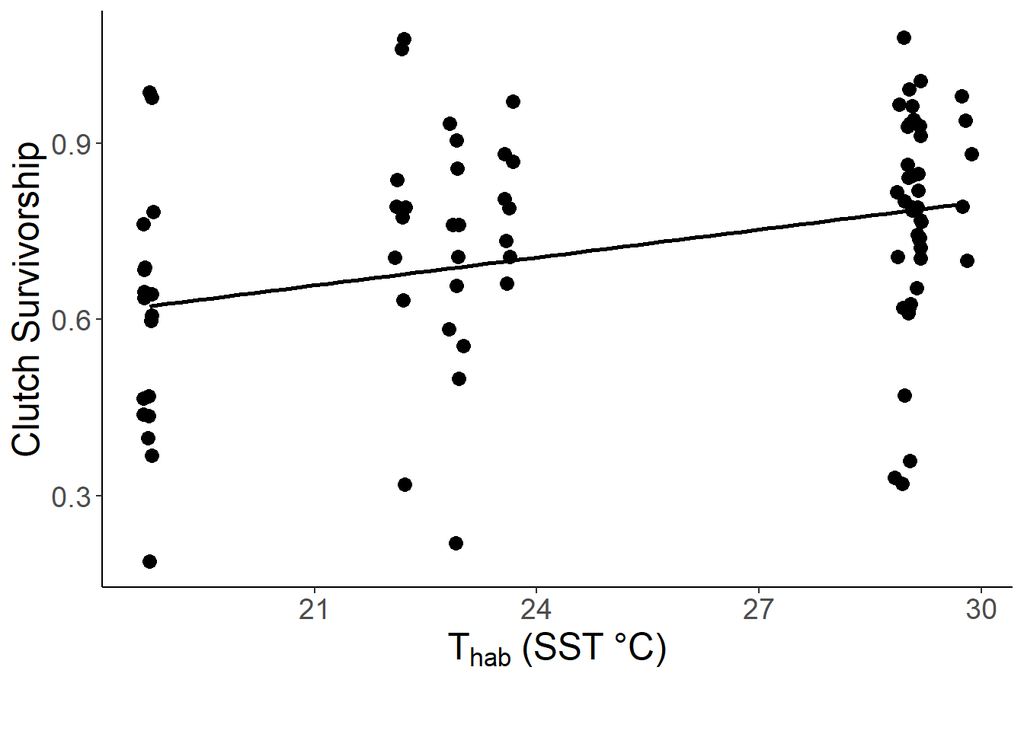

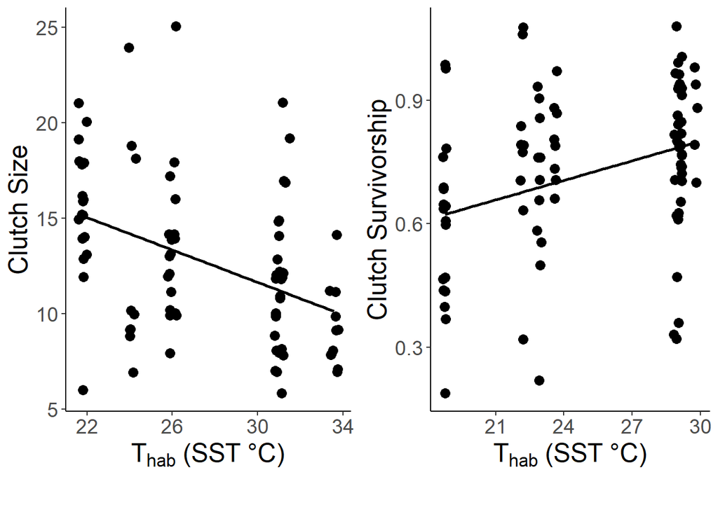